# BankChurn

## Bank Churn Prediction

**Author**: Aidos Utegulov  
**Cohort**: Feb 21

### Objective

Given a Bank customer, build a neural network-based classifier that can determine whether they will leave or not in the next 6 months.

### Data Dictionary

- CustomerId: Unique ID which is assigned to each customer
- Surname: Last name of the customer
- CreditScore: It defines the credit history of the customer.
- Geography: A customer’s location
- Gender: It defines the Gender of the customer
- Age: Age of the customer
- Tenure: Number of years for which the customer has been with the bank
- NumOfProducts: It refers to the number of products that a customer has purchased through the bank.
- Balance: Account balance
- HasCrCard: It is a categorical variable that decides whether the customer has a credit card or not.
- EstimatedSalary: Estimated salary
- isActiveMember: It is a categorical variable that decides whether the customer is an active member of the bank or not ( Active member in the sense, using bank products regularly, making transactions, etc )
- Excited: It is a categorical variable that decides whether the customer left the bank within six months or not. It can take two values

  ```
                0=No ( Customer did not leave the bank )

                1=Yes ( Customer left the bank )
  ```

### Import necessary libraries

```python
#importing tensorflow
import tensorflow as tf
print(tf.__version__)
```

```
2.5.0
```

```python
import pandas as pd
import numpy as np
from sklearn.model_selection import train_test_split
import tensorflow as tf
from sklearn import preprocessing
from tensorflow.keras.models import Sequential
from tensorflow.keras.layers import Dense, Dropout
from sklearn.metrics import accuracy_score, confusion_matrix, precision_score, recall_score, f1_score, precision_recall_curve, auc
import matplotlib.pyplot as plt
from tensorflow.keras import optimizers
from sklearn.decomposition import PCA
import seaborn as sns
from tensorflow import keras
from keras import backend as K
from keras.models import Sequential
from keras.layers import Dense, Dropout
from tensorflow.keras.optimizers import Adam
```

```python
df = pd.read_csv("bank.csv")
```

## Dataset Overview

```python
df.shape
```

```
(10000, 14)
```

```python
df.head(15)
```

|  | RowNumber | CustomerId | Surname | CreditScore | Geography | Gender | Age | Tenure | Balance | NumOfProducts | HasCrCard | IsActiveMember | EstimatedSalary | Exited |
| --- | --- | --- | --- | --- | --- | --- | --- | --- | --- | --- | --- | --- | --- | --- |
| 0 | 1 | 15634602 | Hargrave | 619 | France | Female | 42 | 2 | 0.00 | 1 | 1 | 1 | 101348.88 | 1 |
| 1 | 2 | 15647311 | Hill | 608 | Spain | Female | 41 | 1 | 83807.86 | 1 | 0 | 1 | 112542.58 | 0 |
| 2 | 3 | 15619304 | Onio | 502 | France | Female | 42 | 8 | 159660.80 | 3 | 1 | 0 | 113931.57 | 1 |
| 3 | 4 | 15701354 | Boni | 699 | France | Female | 39 | 1 | 0.00 | 2 | 0 | 0 | 93826.63 | 0 |
| 4 | 5 | 15737888 | Mitchell | 850 | Spain | Female | 43 | 2 | 125510.82 | 1 | 1 | 1 | 79084.10 | 0 |
| 5 | 6 | 15574012 | Chu | 645 | Spain | Male | 44 | 8 | 113755.78 | 2 | 1 | 0 | 149756.71 | 1 |
| 6 | 7 | 15592531 | Bartlett | 822 | France | Male | 50 | 7 | 0.00 | 2 | 1 | 1 | 10062.80 | 0 |
| 7 | 8 | 15656148 | Obinna | 376 | Germany | Female | 29 | 4 | 115046.74 | 4 | 1 | 0 | 119346.88 | 1 |
| 8 | 9 | 15792365 | He | 501 | France | Male | 44 | 4 | 142051.07 | 2 | 0 | 1 | 74940.50 | 0 |
| 9 | 10 | 15592389 | H? | 684 | France | Male | 27 | 2 | 134603.88 | 1 | 1 | 1 | 71725.73 | 0 |
| 10 | 11 | 15767821 | Bearce | 528 | France | Male | 31 | 6 | 102016.72 | 2 | 0 | 0 | 80181.12 | 0 |
| 11 | 12 | 15737173 | Andrews | 497 | Spain | Male | 24 | 3 | 0.00 | 2 | 1 | 0 | 76390.01 | 0 |
| 12 | 13 | 15632264 | Kay | 476 | France | Female | 34 | 10 | 0.00 | 2 | 1 | 0 | 26260.98 | 0 |
| 13 | 14 | 15691483 | Chin | 549 | France | Female | 25 | 5 | 0.00 | 2 | 0 | 0 | 190857.79 | 0 |
| 14 | 15 | 15600882 | Scott | 635 | Spain | Female | 35 | 7 | 0.00 | 2 | 1 | 1 | 65951.65 | 0 |

```python
df.tail(10)
```

|  | RowNumber | CustomerId | Surname | CreditScore | Geography | Gender | Age | Tenure | Balance | NumOfProducts | HasCrCard | IsActiveMember | EstimatedSalary | Exited |
| --- | --- | --- | --- | --- | --- | --- | --- | --- | --- | --- | --- | --- | --- | --- |
| 9990 | 9991 | 15798964 | Nkemakonam | 714 | Germany | Male | 33 | 3 | 35016.60 | 1 | 1 | 0 | 53667.08 | 0 |
| 9991 | 9992 | 15769959 | Ajuluchukwu | 597 | France | Female | 53 | 4 | 88381.21 | 1 | 1 | 0 | 69384.71 | 1 |
| 9992 | 9993 | 15657105 | Chukwualuka | 726 | Spain | Male | 36 | 2 | 0.00 | 1 | 1 | 0 | 195192.40 | 0 |
| 9993 | 9994 | 15569266 | Rahman | 644 | France | Male | 28 | 7 | 155060.41 | 1 | 1 | 0 | 29179.52 | 0 |
| 9994 | 9995 | 15719294 | Wood | 800 | France | Female | 29 | 2 | 0.00 | 2 | 0 | 0 | 167773.55 | 0 |
| 9995 | 9996 | 15606229 | Obijiaku | 771 | France | Male | 39 | 5 | 0.00 | 2 | 1 | 0 | 96270.64 | 0 |
| 9996 | 9997 | 15569892 | Johnstone | 516 | France | Male | 35 | 10 | 57369.61 | 1 | 1 | 1 | 101699.77 | 0 |
| 9997 | 9998 | 15584532 | Liu | 709 | France | Female | 36 | 7 | 0.00 | 1 | 0 | 1 | 42085.58 | 1 |
| 9998 | 9999 | 15682355 | Sabbatini | 772 | Germany | Male | 42 | 3 | 75075.31 | 2 | 1 | 0 | 92888.52 | 1 |
| 9999 | 10000 | 15628319 | Walker | 792 | France | Female | 28 | 4 | 130142.79 | 1 | 1 | 0 | 38190.78 | 0 |

```python
df.info()
```

```
<class 'pandas.core.frame.DataFrame'>
RangeIndex: 10000 entries, 0 to 9999
Data columns (total 14 columns):
 #   Column           Non-Null Count  Dtype
---  ------           --------------  -----
 0   RowNumber        10000 non-null  int64
 1   CustomerId       10000 non-null  int64
 2   Surname          10000 non-null  object
 3   CreditScore      10000 non-null  int64
 4   Geography        10000 non-null  object
 5   Gender           10000 non-null  object
 6   Age              10000 non-null  int64
 7   Tenure           10000 non-null  int64
 8   Balance          10000 non-null  float64
 9   NumOfProducts    10000 non-null  int64
 10  HasCrCard        10000 non-null  int64
 11  IsActiveMember   10000 non-null  int64
 12  EstimatedSalary  10000 non-null  float64
 13  Exited           10000 non-null  int64
dtypes: float64(2), int64(9), object(3)
memory usage: 1.1+ MB
```

```python
df.isna().sum()
```

```
RowNumber          0
CustomerId         0
Surname            0
CreditScore        0
Geography          0
Gender             0
Age                0
Tenure             0
Balance            0
NumOfProducts      0
HasCrCard          0
IsActiveMember     0
EstimatedSalary    0
Exited             0
dtype: int64
```

```python
df.describe().T
```

|  | count | mean | std | min | 25% | 50% | 75% | max |
| --- | --- | --- | --- | --- | --- | --- | --- | --- |
| RowNumber | 10000.0 | 5.000500e+03 | 2886.895680 | 1.00 | 2500.75 | 5.000500e+03 | 7.500250e+03 | 10000.00 |
| CustomerId | 10000.0 | 1.569094e+07 | 71936.186123 | 15565701.00 | 15628528.25 | 1.569074e+07 | 1.575323e+07 | 15815690.00 |
| CreditScore | 10000.0 | 6.505288e+02 | 96.653299 | 350.00 | 584.00 | 6.520000e+02 | 7.180000e+02 | 850.00 |
| Age | 10000.0 | 3.892180e+01 | 10.487806 | 18.00 | 32.00 | 3.700000e+01 | 4.400000e+01 | 92.00 |
| Tenure | 10000.0 | 5.012800e+00 | 2.892174 | 0.00 | 3.00 | 5.000000e+00 | 7.000000e+00 | 10.00 |
| Balance | 10000.0 | 7.648589e+04 | 62397.405202 | 0.00 | 0.00 | 9.719854e+04 | 1.276442e+05 | 250898.09 |
| NumOfProducts | 10000.0 | 1.530200e+00 | 0.581654 | 1.00 | 1.00 | 1.000000e+00 | 2.000000e+00 | 4.00 |
| HasCrCard | 10000.0 | 7.055000e-01 | 0.455840 | 0.00 | 0.00 | 1.000000e+00 | 1.000000e+00 | 1.00 |
| IsActiveMember | 10000.0 | 5.151000e-01 | 0.499797 | 0.00 | 0.00 | 1.000000e+00 | 1.000000e+00 | 1.00 |
| EstimatedSalary | 10000.0 | 1.000902e+05 | 57510.492818 | 11.58 | 51002.11 | 1.001939e+05 | 1.493882e+05 | 199992.48 |
| Exited | 10000.0 | 2.037000e-01 | 0.402769 | 0.00 | 0.00 | 0.000000e+00 | 0.000000e+00 | 1.00 |

**Observations**

### Drop the insignificant columns

```python
df.drop(['RowNumber', 'CustomerId', 'Surname'], axis = 1, inplace = True)
```

```python
df.head()
```

|  | CreditScore | Geography | Gender | Age | Tenure | Balance | NumOfProducts | HasCrCard | IsActiveMember | EstimatedSalary | Exited |
| --- | --- | --- | --- | --- | --- | --- | --- | --- | --- | --- | --- |
| 0 | 619 | France | Female | 42 | 2 | 0.00 | 1 | 1 | 1 | 101348.88 | 1 |
| 1 | 608 | Spain | Female | 41 | 1 | 83807.86 | 1 | 0 | 1 | 112542.58 | 0 |
| 2 | 502 | France | Female | 42 | 8 | 159660.80 | 3 | 1 | 0 | 113931.57 | 1 |
| 3 | 699 | France | Female | 39 | 1 | 0.00 | 2 | 0 | 0 | 93826.63 | 0 |
| 4 | 850 | Spain | Female | 43 | 2 | 125510.82 | 1 | 1 | 1 | 79084.10 | 0 |

## EDA

### Univariate Analysis

```python
# While doing uni-variate analysis of numerical variables we want to study their central tendency
# and dispersion.
# Let us write a function that will help us create boxplot and histogram for any input numerical
# variable.
# This function takes the numerical column as the input and returns the boxplots
# and histograms for the variable.
# Let us see if this help us write faster and cleaner code.
def histogram_boxplot(feature, figsize=(15,10), bins = None):
    """ Boxplot and histogram combined
    feature: 1-d feature array
    figsize: size of fig (default (9,8))
    bins: number of bins (default None / auto)
    """
    f2, (ax_box2, ax_hist2) = plt.subplots(nrows = 2, # Number of rows of the subplot grid= 2
                                           sharex = True, # x-axis will be shared among all subplots
                                           gridspec_kw = {"height_ratios": (.25, .75)},
                                           figsize = figsize
                                           ) # creating the 2 subplots
    sns.boxplot(feature, ax=ax_box2, showmeans=True, color='violet') # boxplot will be created and a star will indicate the mean value of the column
    sns.distplot(feature, kde=F, ax=ax_hist2, bins=bins,palette="winter") if bins else sns.distplot(feature, kde=False, ax=ax_hist2) # For histogram
    ax_hist2.axvline(np.mean(feature), color='green', linestyle='--') # Add mean to the histogram
    ax_hist2.axvline(np.median(feature), color='black', linestyle='-') # Add median to the histogram
```

```python
def perc_on_bar(feature):
    """
    plot
    feature: categorical feature
    the function won't work if a column is passed in the hue parameter
    """
    # Creating a countplot for the feature
    sns.set(rc={"figure.figsize": (10, 5)})
    ax = sns.countplot(x=feature, data=df)

    total = len(feature)  # length of the column
    for p in ax.patches:
        percentage = "{:.1f}%".format(
            100 * p.get_height() / total
        )  # percentage of each class of the category
        x = p.get_x() + p.get_width() / 2 - 0.1  # width of the plot
        y = p.get_y() + p.get_height()  # hieght of the plot
        ax.annotate(percentage, (x, y), size=14)  # annotate the percantage

    plt.show()  # show the plot
```

### Observations on Age

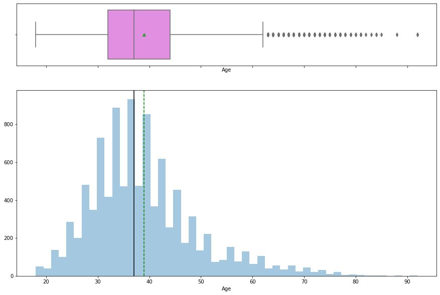

```python
import warnings
warnings.filterwarnings("ignore")
histogram_boxplot(df['Age'])
```

**Observations**

### Observations on Credit Score

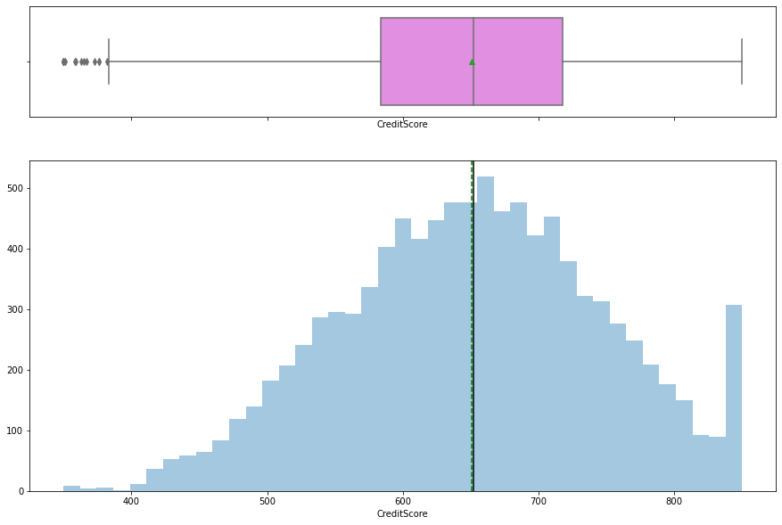

```python
histogram_boxplot(df['CreditScore'])
```

**Observations**

- There is some skewness to the left
- There seem to be outliers on the left side

### Observations on Estimated Salary

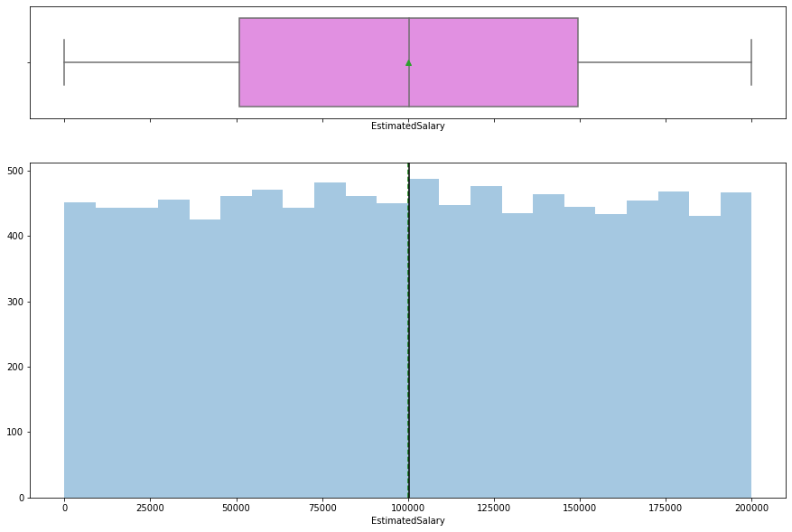

```python
histogram_boxplot(df['EstimatedSalary'])
```

### Observations on Tenure

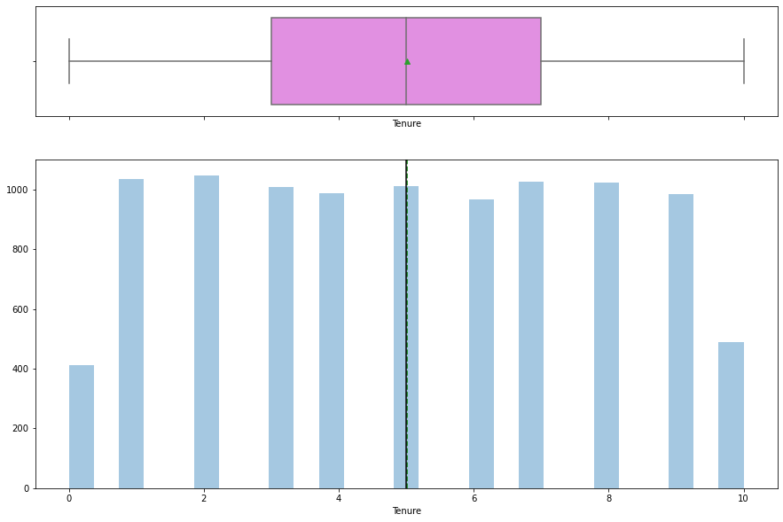

```python
histogram_boxplot(df['Tenure'])
```

### Observations on Balance

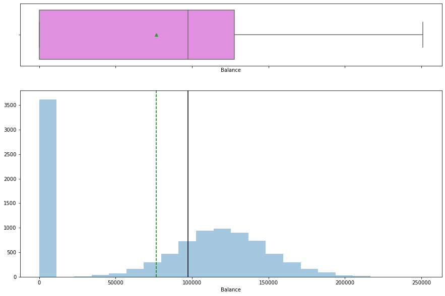

```python
histogram_boxplot(df['Balance'])
```

- Data are left-skewed, there is quite a lot of customers on the left, with account balance in lower range

### Observations on number of purchased products

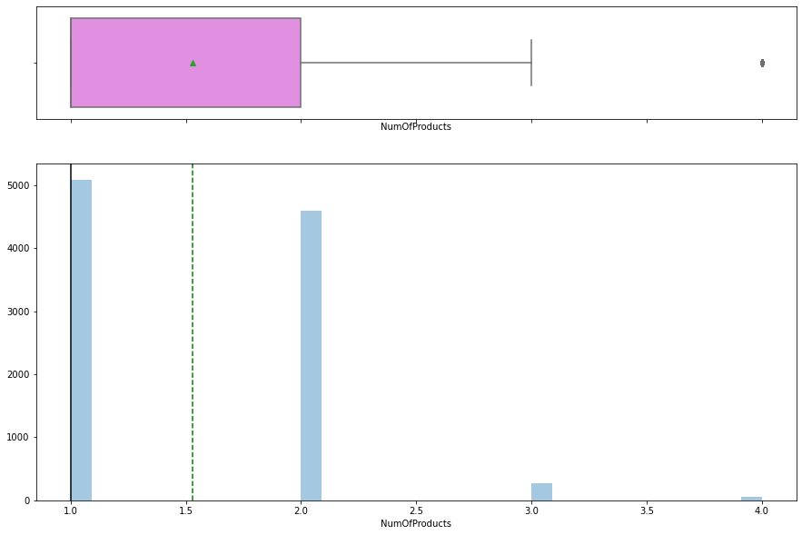

```python
histogram_boxplot(df['NumOfProducts'])
```

- Most people bought 1 or 2 products through the bank, there are some outliers however.

### Observations on whether the customer left or not

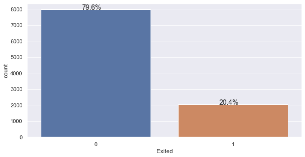

```python
perc_on_bar(df['Exited'])
```

- Only 20.4% of customers have left. Data is imbalanced. Might need to impute values

### Observations on Gender

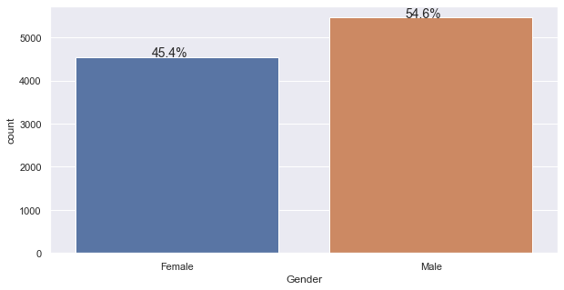

```python
perc_on_bar(df['Gender'])
```

- More than a half of the customers are male, 45% of customers are female

### Observations on Geography

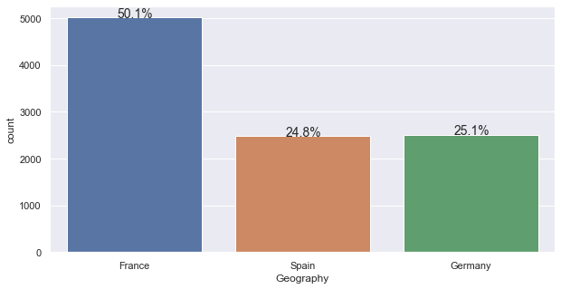

```python
perc_on_bar(df['Geography'])
```

- half of the customers are from France, a quarter are from Germany and another quarter - from Spain
- We can convert this column to numerical, which will give us 2 more columns (1 dropped)

### Observations whether a customer has a credit card

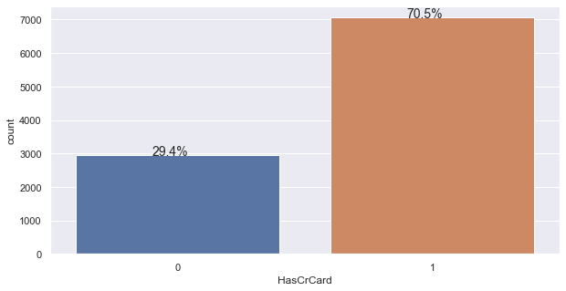

```python
perc_on_bar(df['HasCrCard'])
```

- 70.5% of customers have credit cards, the rest don't have one

### Observations whether a customer is an active member

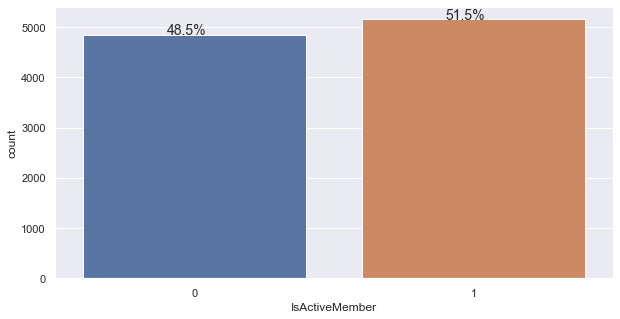

```python
perc_on_bar(df['IsActiveMember'])
```

- Data are almost evenly split, with slightly more people being active customers

## Get Dummies for categorical variables

```python
df = pd.get_dummies(df, drop_first = True)
```

```python
df.head()
```

|  | CreditScore | Age | Tenure | Balance | NumOfProducts | HasCrCard | IsActiveMember | EstimatedSalary | Exited | Geography_Germany | Geography_Spain | Gender_Male |
| --- | --- | --- | --- | --- | --- | --- | --- | --- | --- | --- | --- | --- |
| 0 | 619 | 42 | 2 | 0.00 | 1 | 1 | 1 | 101348.88 | 1 | 0 | 0 | 0 |
| 1 | 608 | 41 | 1 | 83807.86 | 1 | 0 | 1 | 112542.58 | 0 | 0 | 1 | 0 |
| 2 | 502 | 42 | 8 | 159660.80 | 3 | 1 | 0 | 113931.57 | 1 | 0 | 0 | 0 |
| 3 | 699 | 39 | 1 | 0.00 | 2 | 0 | 0 | 93826.63 | 0 | 0 | 0 | 0 |
| 4 | 850 | 43 | 2 | 125510.82 | 1 | 1 | 1 | 79084.10 | 0 | 0 | 1 | 0 |

```python
df.info()
```

```
<class 'pandas.core.frame.DataFrame'>
RangeIndex: 10000 entries, 0 to 9999
Data columns (total 12 columns):
 #   Column             Non-Null Count  Dtype
---  ------             --------------  -----
 0   CreditScore        10000 non-null  int64
 1   Age                10000 non-null  int64
 2   Tenure             10000 non-null  int64
 3   Balance            10000 non-null  float64
 4   NumOfProducts      10000 non-null  int64
 5   HasCrCard          10000 non-null  int64
 6   IsActiveMember     10000 non-null  int64
 7   EstimatedSalary    10000 non-null  float64
 8   Exited             10000 non-null  int64
 9   Geography_Germany  10000 non-null  uint8
 10  Geography_Spain    10000 non-null  uint8
 11  Gender_Male        10000 non-null  uint8
dtypes: float64(2), int64(7), uint8(3)
memory usage: 732.5 KB
```

**Observations**

- Now all of our columns are numeric, France was dropped in the geography column and female was dropped from genders

## Bivariate Analysis

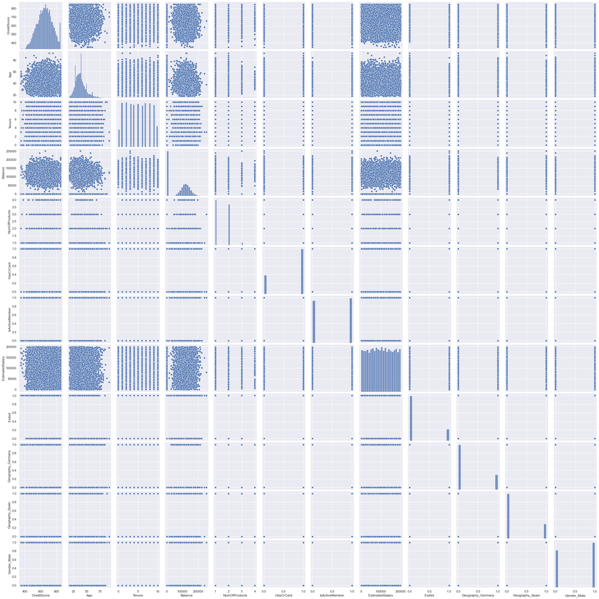

```python
sns.pairplot(df)
```

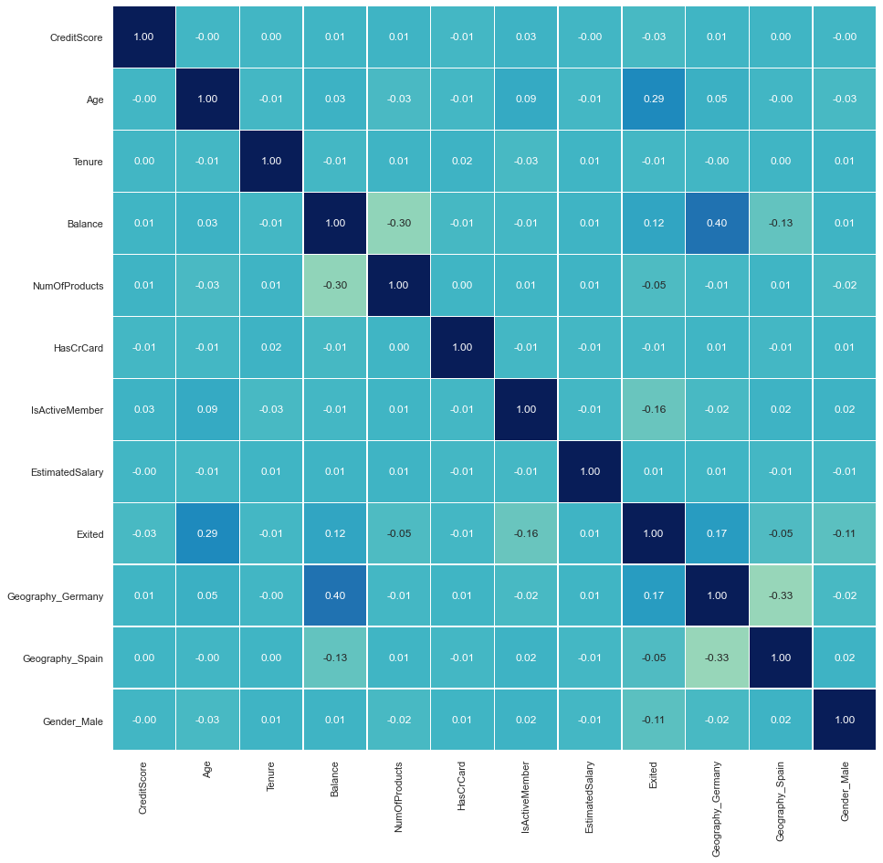

```python
sns.set(rc={"figure.figsize": (15, 15)})
sns.heatmap(
    df.corr(),
    annot=True,
    linewidths=0.5,
    center=0,
    cbar=False,
    cmap="YlGnBu",
    fmt="0.2f",
)
plt.show()
```

**Observations**

- There's really not much correlation between features in the dataset, the highest one being that of Balance and Geography_Germany (0.40).
- There's also correlation between Age and Exited (0.29), but it is not very significant
- The pairplots also show no collinearity between any two features

## Splitting the dataset

```python
from sklearn.model_selection import train_test_split
X = df.drop(['Exited'], axis = 1)
y = df['Exited']
```

```python
#Splitting the training and test set
X_train, X_test, y_train, y_test = train_test_split(X, y, test_size=0.20, random_state=1)
```

### Rescale the data

```python
from sklearn.preprocessing import StandardScaler

# Define the scaler
scaler = StandardScaler().fit(X_train)

# Scale the train set
X_train = scaler.transform(X_train)

# Scale the test set
X_test = scaler.transform(X_test)

X_val = scaler.transform(X_val)
```

```python
X_train.shape
```

```
(8000, 11)
```

## Define model architecture

```python
model = Sequential()
```

```python
model.add(Dense(11,activation='relu'))
model.add(Dense(100, activation ='relu'))
model.add(Dense(1,activation='sigmoid'))
```

**Observations**

- I first choose to go with a simple model with one hidden layer and later will try to improve it by adding additional layers
- Input layer contains 11 neurons for the number of columns, the hidden layer contains 100 neurons and the output layer contains only one neuron with the sigmoid activation function
- Next I compile the model, choosing Adam as my optimizer and binary_crossentropy as my loss function

```python
model.compile(loss='binary_crossentropy',optimizer='adam',metrics=['accuracy'])
```

```python
model.fit(X_train, y_train, epochs=10, batch_size=256, verbose=1)
```

```
<keras.callbacks.History at 0x2a22ecddc40>
```

**Observations**

```python
loss, acc = model.evaluate(X_test, y_test, verbose=0)
print('Accuracy: %.3f'  % acc)
print('Loss: %.3f' % loss)
```

```
Accuracy: 0.841
Loss: 0.385
```

### Confusion Matrix

Here I'm using the confusion matrix function given to us during mentoring session

```python
def make_confusion_matrix(cf,
                          group_names=None,
                          categories='auto',
                          count=True,
                          percent=True,
                          cbar=True,
                          xyticks=True,
                          xyplotlabels=True,
                          sum_stats=True,
                          figsize=None,
                          cmap='Blues',
                          title=None):
    '''
    This function will make a pretty plot of an sklearn Confusion Matrix cm using a Seaborn heatmap visualization.
    Arguments
    '''


    # CODE TO GENERATE TEXT INSIDE EACH SQUARE
    blanks = ['' for i in range(cf.size)]

    if group_names and len(group_names)==cf.size:
        group_labels = ["{}\n".format(value) for value in group_names]
    else:
        group_labels = blanks

    if count:
        group_counts = ["{0:0.0f}\n".format(value) for value in cf.flatten()]
    else:
        group_counts = blanks

    if percent:
        group_percentages = ["{0:.2%}".format(value) for value in cf.flatten()/np.sum(cf)]
    else:
        group_percentages = blanks

    box_labels = [f"{v1}{v2}{v3}".strip() for v1, v2, v3 in zip(group_labels,group_counts,group_percentages)]
    box_labels = np.asarray(box_labels).reshape(cf.shape[0],cf.shape[1])


    # CODE TO GENERATE SUMMARY STATISTICS & TEXT FOR SUMMARY STATS
    if sum_stats:
        #Accuracy is sum of diagonal divided by total observations
        accuracy  = np.trace(cf) / float(np.sum(cf))

        #if it is a binary confusion matrix, show some more stats
        if len(cf)==2:
            #Metrics for Binary Confusion Matrices
            precision = cf[1,1] / sum(cf[:,1])
            recall    = cf[1,1] / sum(cf[1,:])
            f1_score  = 2*precision*recall / (precision + recall)
            stats_text = "\n\nAccuracy={:0.3f}\nPrecision={:0.3f}\nRecall={:0.3f}\nF1 Score={:0.3f}".format(
                accuracy,precision,recall,f1_score)
        else:
            stats_text = "\n\nAccuracy={:0.3f}".format(accuracy)
    else:
        stats_text = ""


    # SET FIGURE PARAMETERS ACCORDING TO OTHER ARGUMENTS
    if figsize==None:
        #Get default figure size if not set
        figsize = plt.rcParams.get('figure.figsize')

    if xyticks==False:
        #Do not show categories if xyticks is False
        categories=False


    # MAKE THE HEATMAP VISUALIZATION
    plt.figure(figsize=figsize)
    sns.heatmap(cf,annot=box_labels,fmt="",cmap=cmap,cbar=cbar,xticklabels=categories,yticklabels=categories)

    if xyplotlabels:
        plt.ylabel('True label')
        plt.xlabel('Predicted label' + stats_text)
    else:
        plt.xlabel(stats_text)

    if title:
        plt.title(title)
```

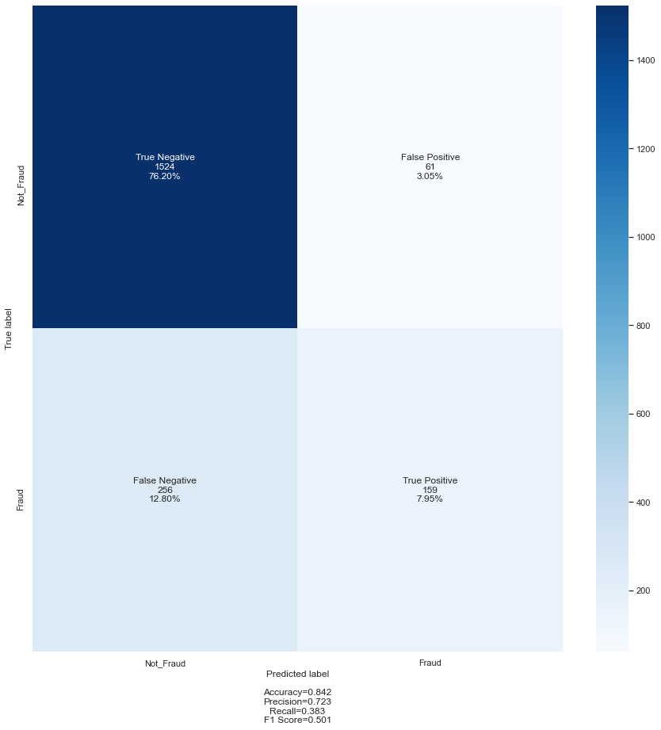

```python
import seaborn as sn
y_pred1 = model.predict(X_test)
for i in range(len(y_test)):
    if y_pred1[i]>0.5:
        y_pred1[i]=1
    else:
        y_pred1[i]=0



cm2=confusion_matrix(y_test, y_pred1)
labels = ['True Negative','False Positive','False Negative','True Positive']
categories = [ 'Not_Fraud','Fraud']
make_confusion_matrix(cm2,
                      group_names=labels,
                      categories=categories,
                      cmap='Blues')
```

**Observations**

### Finding Optimal Thresholds

```python
y_pred2 = model.predict(X_train)
y_pred2 = y_pred2[:,0]
y_pred2 = np.where(y_pred2 > 0.5, 1, 0)
y_pred2
```

```
array([0, 0, 0, ..., 0, 0, 1])
```

Let's use roc-auc score to try and find optimal thresholds

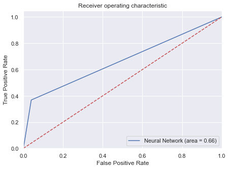

```python
from sklearn.metrics import roc_auc_score, roc_curve, accuracy_score, recall_score, precision_score



logit_roc_auc_train = roc_auc_score(y_train, y_pred2)
fpr, tpr, thresholds = roc_curve(y_train, y_pred2)
plt.figure(figsize=(7,5))
plt.plot(fpr, tpr, label='Neural Network (area = %0.2f)' % logit_roc_auc_train)
plt.plot([0, 1], [0, 1],'r--')
plt.xlim([0.0, 1.0])
plt.ylim([0.0, 1.05])
plt.xlabel('False Positive Rate')
plt.ylabel('True Positive Rate')
plt.title('Receiver operating characteristic')
plt.legend(loc="lower right")
plt.show()
```

```python
fpr, tpr, thresholds = roc_curve(y_test, y_pred1)

optimal_idx = np.argmax(tpr - fpr)
optimal_threshold = thresholds[optimal_idx]
print(optimal_threshold)
```

```
1.0
```

**Observations**

- The optimal threshold of 1.0 gives us 0 values for precision and recall, this was a waste...
- Let's still choose a threshold of 0.3 and see

```python
optimal_threshold = 0.3
# Model prediction with optimal threshold
pred_train_opt = (model.predict(X_train)>optimal_threshold).astype(int)
pred_test_opt = (model.predict(X_test)>optimal_threshold).astype(int)
```

```python
#Model performance with optimal threhold

print('Accuracy on train data:',accuracy_score(y_train, pred_train_opt) )
print('Accuracy on test data:',accuracy_score(y_test, pred_test_opt))

print('Recall on train data:',recall_score(y_train, pred_train_opt))
print('Recall on test data:',recall_score(y_test, pred_test_opt))

print('Precision on train data:',precision_score(y_train, pred_train_opt) )
print('Precision on test data:',precision_score(y_test, pred_test_opt))
```

```
Accuracy on train data: 0.8065
Accuracy on test data: 0.807
Recall on train data: 0.6165228113440198
Recall on test data: 0.6048192771084338
Precision on train data: 0.5192107995846313
Precision on test data: 0.5306553911205074
```

**Observations**

- Choosing the optimal threshold of 0.3 gives us 80% accuracy, 60% recall and 53% precision on the test set
- I really don't understand why optimal threshold calculation gave me 1.0, but the value of 0.3 seems to give best scores
- In context of churn, recall would be a more important metric, since we need to predict the customers that will leave the bank. This is why choosing an optimal threshold and maximizing recall works in this case.
- Let's try a different model with more layers

## A second model with more layers

This time let us add a couple more Dense layers and a dropout layer to prevent overfitting

```python
model2 = Sequential()
```

```python
model2.add(Dense(units=16, input_dim = 11,activation='relu'))
model2.add(Dense(24, activation ='relu'))
#Adding Dropout to prevent overfitting
model2.add(Dropout(0.5))
model2.add(Dense(24,activation='relu'))
model2.add(Dense(24,activation='relu'))
model2.add(Dense(1,activation='sigmoid'))
```

```python
# Create optimizer with default learning rate
# Compile the model
model2.compile(optimizer='adam',loss='binary_crossentropy',metrics=['accuracy'])
```

```python
model2.summary()
```

```
Model: "sequential_3"
_________________________________________________________________
Layer (type)                 Output Shape              Param #
=================================================================
dense_11 (Dense)             (None, 16)                192
_________________________________________________________________
dense_12 (Dense)             (None, 24)                408
_________________________________________________________________
dropout_1 (Dropout)          (None, 24)                0
_________________________________________________________________
dense_13 (Dense)             (None, 24)                600
_________________________________________________________________
dense_14 (Dense)             (None, 24)                600
_________________________________________________________________
dense_15 (Dense)             (None, 1)                 25
=================================================================
Total params: 1,825
Trainable params: 1,825
Non-trainable params: 0
_________________________________________________________________
```

```python
#fitting the model
history=model2.fit(X_train,y_train,batch_size=15,epochs=10,validation_split=0.2)
```

### Plotting the train and test loss

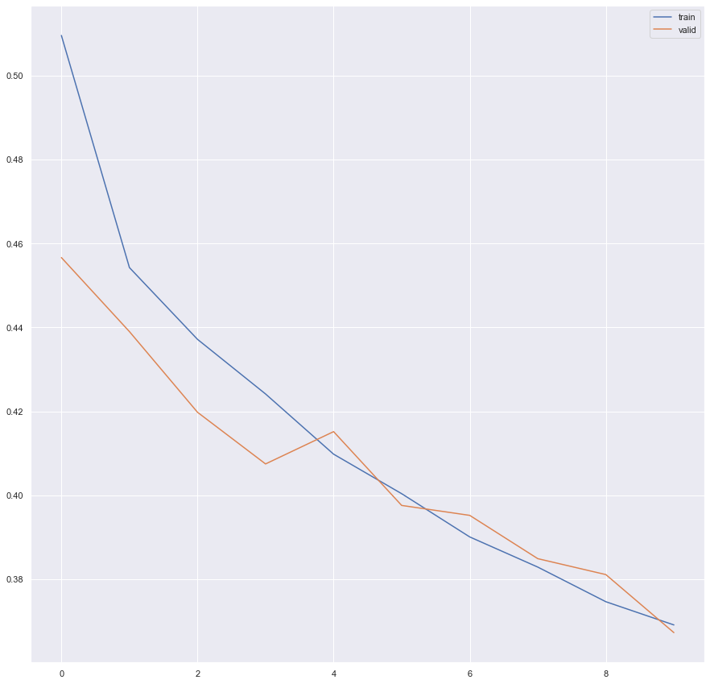

```python
# Capturing learning history per epoch
hist  = pd.DataFrame(history.history)
hist['epoch'] = history.epoch

# Plotting accuracy at different epochs
plt.plot(hist['loss'])
plt.plot(hist['val_loss'])
plt.legend(("train" , "valid") , loc =0)
```

## Model Evaluation

```python
score = model2.evaluate(X_test, y_test)
```

### Confusion Matrix

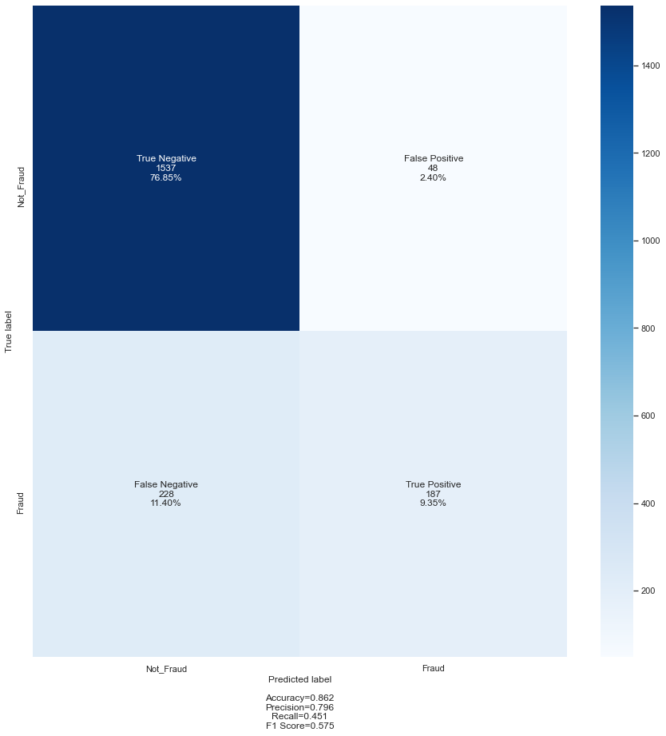

```python
## Confusion Matrix on unsee test set
import seaborn as sn
y_pred1_model2 = model2.predict(X_test)
for i in range(len(y_test)):
    if y_pred1_model2[i]>0.5:
        y_pred1_model2[i]=1
    else:
        y_pred1_model2[i]=0



cm2=confusion_matrix(y_test, y_pred1_model2)
labels = ['True Negative','False Positive','False Negative','True Positive']
categories = [ 'Not_Fraud','Fraud']
make_confusion_matrix(cm2,
                      group_names=labels,
                      categories=categories,
                      cmap='Blues')
```

**Observations**

- This model gives slightly better scores, especially in terms of recall 45% - there's a good chance we can maximize it, accuracy is also higher - 86%

```python
y_pred2_model2 = model2.predict(X_train)
y_pred2_model2 = y_pred2_model2[:,0]
y_pred2_model2 = np.where(y_pred2 > 0.5, 1, 0)
y_pred2_model2
```

```
array([0, 0, 0, ..., 0, 0, 1])
```

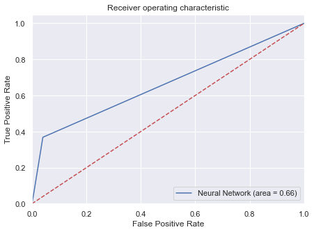

```python
logit_roc_auc_train = roc_auc_score(y_train, y_pred2_model2)
fpr, tpr, thresholds = roc_curve(y_train, y_pred2_model2)
plt.figure(figsize=(7,5))
plt.plot(fpr, tpr, label='Neural Network (area = %0.2f)' % logit_roc_auc_train)
plt.plot([0, 1], [0, 1],'r--')
plt.xlim([0.0, 1.0])
plt.ylim([0.0, 1.05])
plt.xlabel('False Positive Rate')
plt.ylabel('True Positive Rate')
plt.title('Receiver operating characteristic')
plt.legend(loc="lower right")
plt.show()
```

### Using Precision-Recall Curve for thresholds

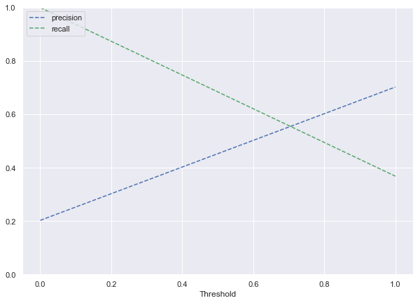

```python
prec, rec, tre = precision_recall_curve(y_train, y_pred2_model2,)

def plot_prec_recall_vs_tresh(precisions, recalls, thresholds):
    plt.plot(thresholds, precisions[:-1], 'b--', label='precision')
    plt.plot(thresholds, recalls[:-1], 'g--', label = 'recall')
    plt.xlabel('Threshold')
    plt.legend(loc='upper left')
    plt.ylim([0,1])
plt.figure(figsize=(10,7))
plot_prec_recall_vs_tresh(prec, rec, tre)
plt.show()
```

```python
optimal_thresholds = [0.13, 0.23, 0.33, 0.43]
for optimal_threshold in optimal_thresholds:
    print('Optimal threshold of ', optimal_threshold)
    # Model prediction with optimal threshold
    pred_train_opt = (model2.predict(X_train)>optimal_threshold).astype(int)
    pred_test_opt = (model2.predict(X_test)>optimal_threshold).astype(int)

    #Model performance with optimal threhold

    print('Accuracy on train data:',accuracy_score(y_train, pred_train_opt) )
    print('Accuracy on test data:',accuracy_score(y_test, pred_test_opt))

    print('Recall on train data:',recall_score(y_train, pred_train_opt))
    print('Recall on test data:',recall_score(y_test, pred_test_opt))

    print('Precision on train data:',precision_score(y_train, pred_train_opt) )
    print('Precision on test data:',precision_score(y_test, pred_test_opt))

    print('ROC-AUC Score on train data:',roc_auc_score(y_train, pred_train_opt) )
    print('ROC-AUC Score on test data:',roc_auc_score(y_test, pred_test_opt))
    print('=' * 40)
```

```
Optimal threshold of  0.13
Accuracy on train data: 0.539375
Accuracy on test data: 0.5365
Recall on train data: 0.9327990135635018
Recall on test data: 0.9397590361445783
Precision on train data: 0.29730791904106896
Precision on test data: 0.3018575851393189
ROC-AUC Score on train data: 0.6860608426237076
ROC-AUC Score on test data: 0.6853369313215005
========================================
Optimal threshold of  0.23
Accuracy on train data: 0.7905
Accuracy on test data: 0.7985
Recall on train data: 0.7114673242909988
Recall on test data: 0.7180722891566265
Precision on train data: 0.48856900931414055
Precision on test data: 0.5102739726027398
ROC-AUC Score on train data: 0.7610331290630283
ROC-AUC Score on test data: 0.7688153243890388
========================================
Optimal threshold of  0.33
Accuracy on train data: 0.848625
Accuracy on test data: 0.8455
Recall on train data: 0.5739827373612824
Recall on test data: 0.563855421686747
Precision on train data: 0.6416264645072364
Precision on test data: 0.6464088397790055
ROC-AUC Score on train data: 0.7462262385458026
ROC-AUC Score on test data: 0.7415491619474746
========================================
Optimal threshold of  0.43
Accuracy on train data: 0.855625
Accuracy on test data: 0.855
Recall on train data: 0.4833538840937115
Recall on test data: 0.4843373493975904
Precision on train data: 0.7120799273387829
Precision on test data: 0.7256317689530686
ROC-AUC Score on train data: 0.7168258915608099
ROC-AUC Score on test data: 0.7181939112918552
========================================
```

**Observations**

- We can get the maximum value of recall at the threshold of 0.13, but that gives us poor performance in the remaining metrics. A more balanced set of scores can be achieved by choosing the optimal threshold value of 0.33: we get recall that is higher than 50% and we get the accuracy of 85%, which is quite good, also precision and f1-score are good. So, personally, I would choose the threshold of 0.33 for optimal values of the required metrics